# Внешний курс

Криптография

Солдатов А. Е

Российский университет дружбы народов, Москва, Россия

НКАбд-04-23

9 мая 2025

## Докладчик

- Солдатов Алексей Евгеньевич
- Студент
- НКАбд-04-23
- Российский университет дружбы народов
- 1132236009@pfur.ru

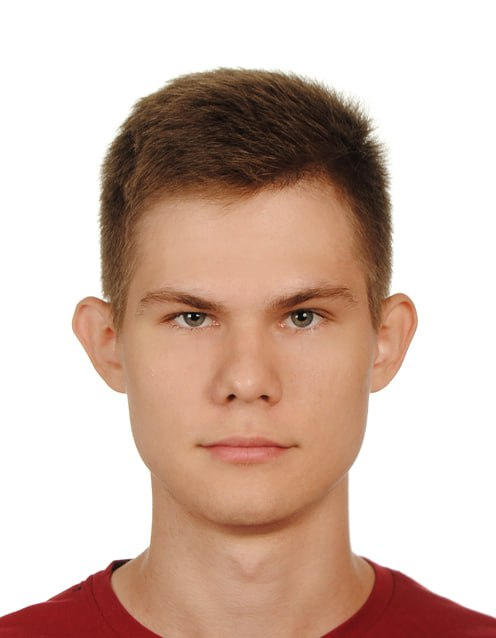

## Выполнение блока 1 (Введение в криптографию)

После просмотра видеоматериала приступил к выполнению заданий

В видеолекции было рассказано, что в асимметричных примитивах обе стороны имеют пару ключей (рис. 1 [-@fig:001]).

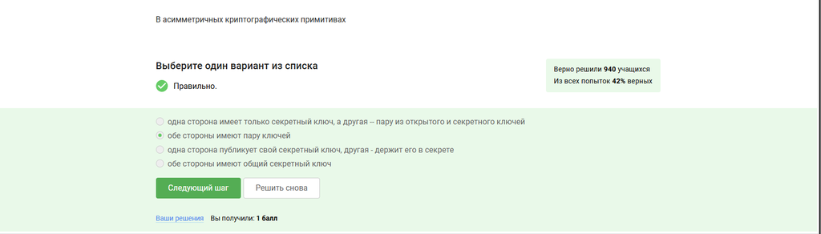

Асимметричный примитив

В видеолекции было рассказано о свойствах криптографической хэш-функции (рис. 2 [-@fig:002]).

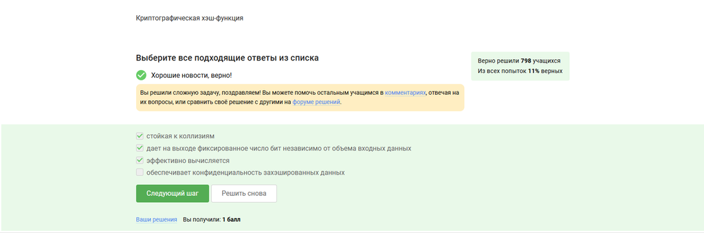

Хэш-функция

В видеолекции было рассказано, что относится к алгоритмам цифровой подписи (рис. 3 [-@fig:003]).

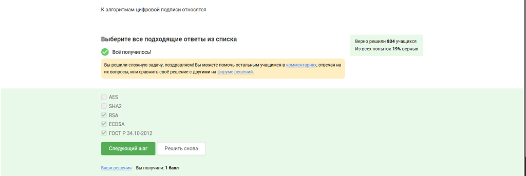

Примеры

В видеолекции было сказано, что код аутентификации сообщения относится к симметричным примитивам (рис. 4 [-@fig:004]).

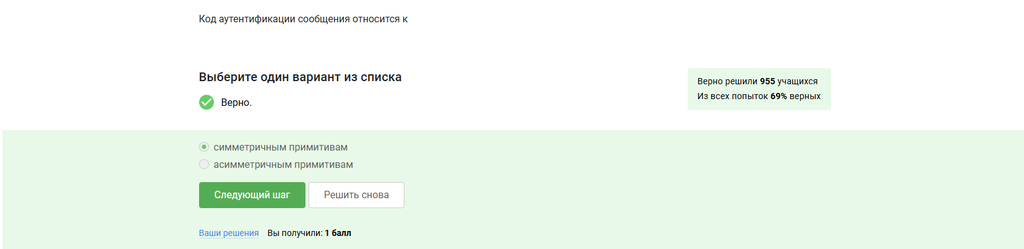

Код аутентификации

В видеолекции было рассказано, что такое обмен ключами Диффи-Хэллмана (рис. 5 [-@fig:005]).

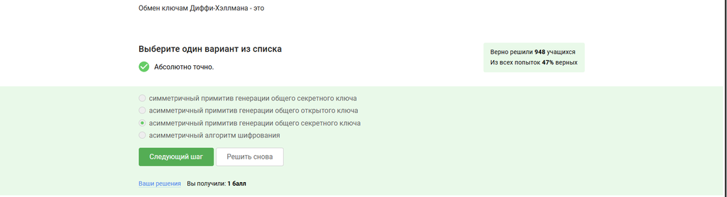

Обмен ключами Диффи-Хэллмана

# Выполнение блока 2 (Цифровая подпись)

В видеолекции было сказано, что протокол электронной цифровой подписи относится к протоколам с публичным ключом (рис. 6 [-@fig:006]).

[figure not shown]

Эл. циф. подпись

В видеолекции было рассказано что требует алгоритм верификации эл. циф. подписи (рис. 7 [-@fig:007]).

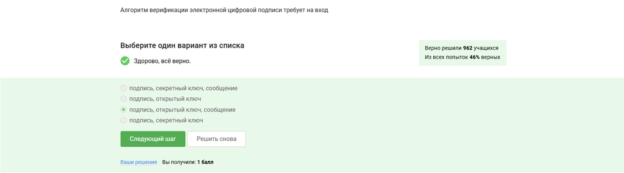

Что требует алгоритм

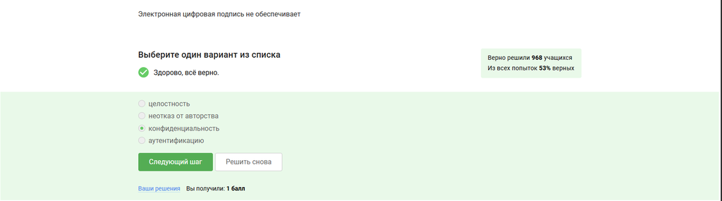

Что не обеспечивает эл. циф. подпись

В видеолекции было рассказано, какой тип сертификата эл. циф. подписи понадобится для отправки в налоговую (рис. 9 [-@fig:009]).

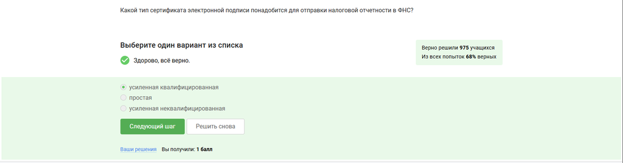

Отчетность ФНС

В видеолекции было сказано, в какой организации можно получить квалифицированный сертификат ключа проверки эл. подписи (рис. 10 [-@fig:010]).

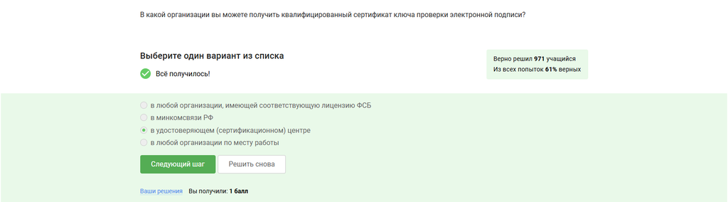

Удостоверяющий центр

# Выполнение блока 3 (Электронные платежа)

В видеолекции было рассказано о некторых из платежных систем (рис. 11 [-@fig:011]).

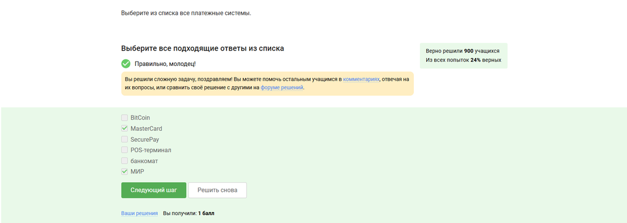

Платежные системы

В видеолекции было рассказано, что является примером многофакторной аутентификации (рис. 12 [-@fig:012]).

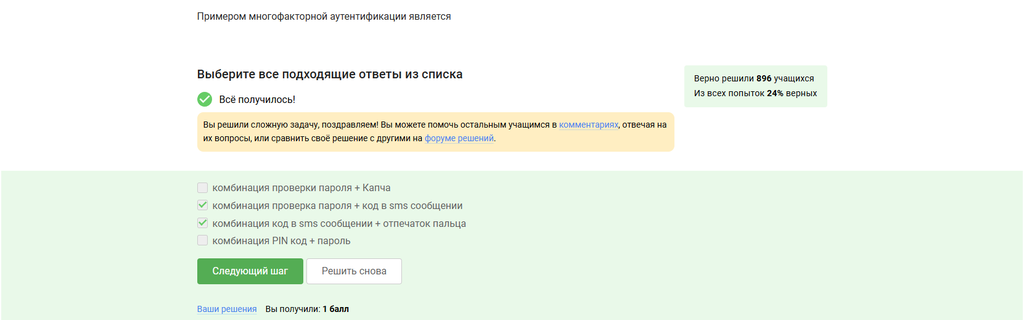

Многофакторная аутентификация

В видеолекции было рассказано, что используется при онлайн платежах (рис. 13 [-@fig:013]).

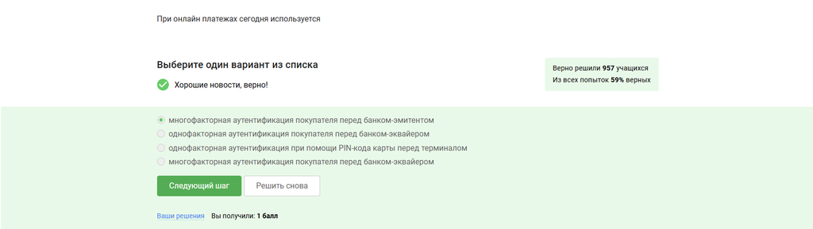

Онлайн платежи

# Выполнение блока 4 (Блокчейн)

В видеолекции было рассказано, какое свойство криптографической хэш-функции используется в доказательстве работы (рис. 14 [-@fig:014]).

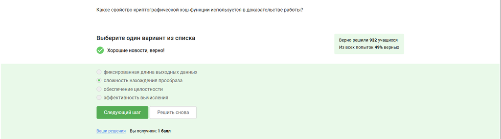

Сложность нахождения прообраза

В видеолекции было рассказано, какими свойствами обладает консенсус (рис. 15 [-@fig:015]).

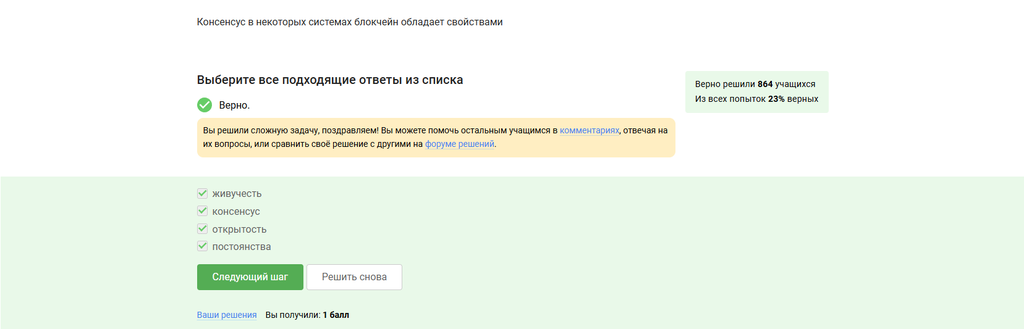

Консенсус

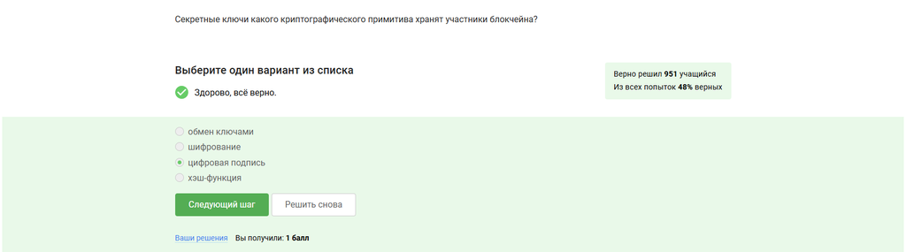

Что хранят участники блокчейна

# Выводы

Получил полезные знания и прошел тесты по теме криптография